# Project 1

Noam Ghenassia, Maïlis Fontani, Julia Morin

2022-10-29

## Introduction

In this project, we will analyse data from the IPUMS USA database, which provides access to over sixty integrated, high-precision samples of the American population drawn from sixteen federal censuses (Source : https://usa.ipums.org/usa-action/variables/group)

We wanted in particular to observe the effects of education and origin on the income in the American population. We were inspired by a study “The Employment of Low-Skilled Immigrant Men in the United States” (Brian Duncan Stephen J. Trejo, American Economic Review, May 2012) that claims that among people with the lowest education levels, immigrants exhibit substantially higher rates of employment than comparable natives.

In this purpose, we selected a sample from year 2000. It consists of 2808457 observations together with the origin of the individuals (they are classified in 9 categories: white, black/African american, Chinese…), their income and their educational levels (12 categories from *No Schooling* to *5+ years of college*).

## Analysis

To find relations between our different variables, we start to compare the income and the origin of the individuals. Let us start with a boxplot of the income for each of the origin to see how income is distributed. Here we plot the logarithm of the incomes : this prevents the outliers with higher income from hiding the variability among the lower levels of income, and allows for all the orders of magnitude of income to fit in the same plot.

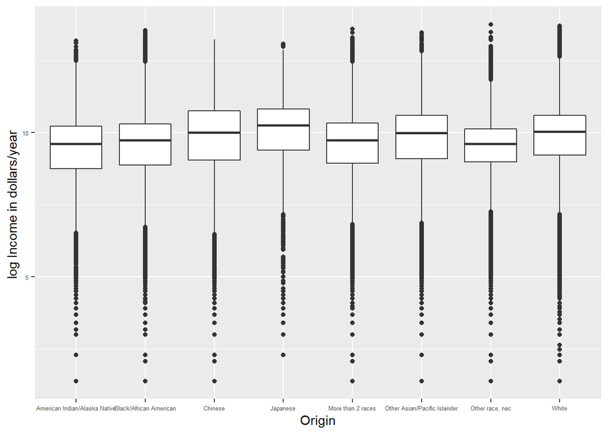

The diagram does not seem to show outstanding differences between the different origins. The highest income median is for the Japanese population (with an income around exp(10) = 22000 US-dollars). The three following highest median are for the Chinese, White and other Asians or Pacific Islanders. It can also be observed that the highest variance stands for the Chinese. Japanese and Chinese are also the populations with less outliers with a high income. The lowest incomes of the Japanese population are also way higher than those of the other categories.

We now process to the same diagram with two boxplots showing the income for two categories of our observations : individuals that attempted school until the 12th grade and the ones that did at least one year of college.

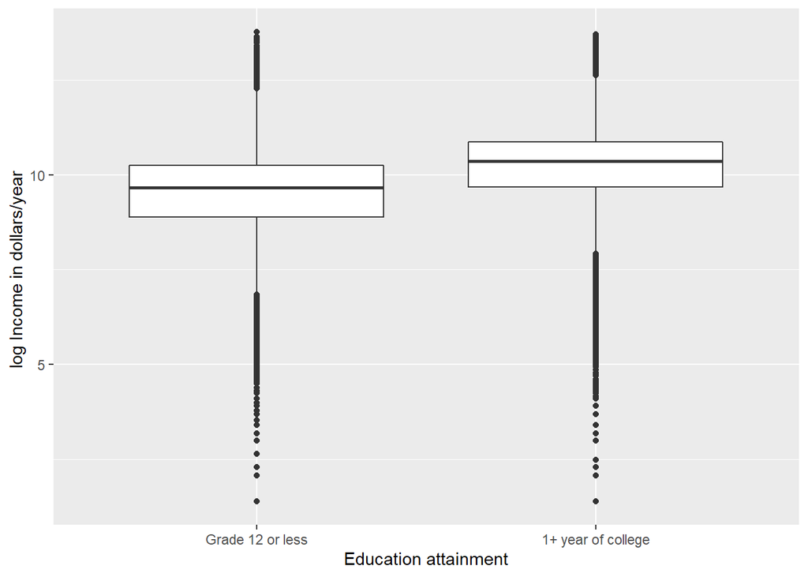

The second category, i.e. the workers that had a better level of education gets highest incomes overall. Variance and outliers seems to be similar. To have a more precise idea, we can do more boxplots with a broadest range of category to be more precise on the flow of income :

[figure not shown]

To get a more holistic vision of our data, we produced a heatmap that links all the variables in one diagram.

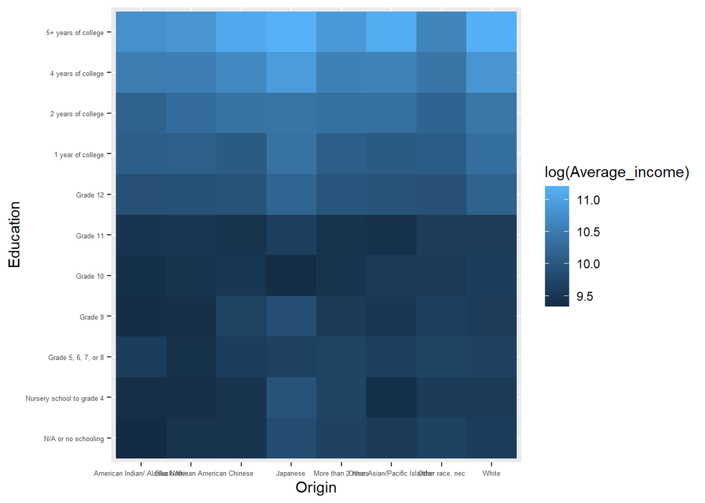

We observe that the difference of income is more important between the rows than the columns. This is linked to the analysis we had with the boxplots. The incomes tends to depend more one the education levels than the origins.

We will now perform Kernel Density Estimation for the income distribution, for each education level or origin, and will compare these plots. We use a Gaussian kernel.

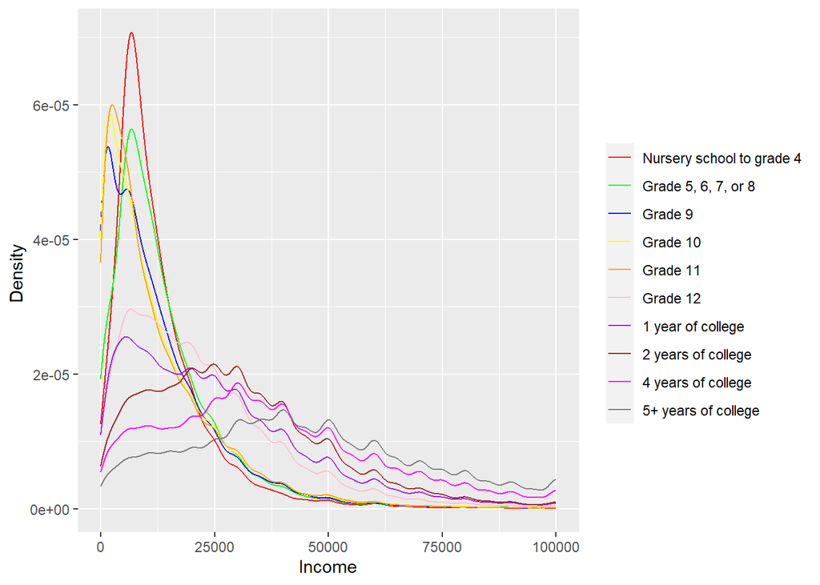

The bandwidth for the KDE was chosen by simply trying several values. The retained value of 1600 seems to offer a good tradeoff between bias and variance : indeed, the curves are relatively smooth, but still show a small peak on multiples of 10000. This is likely due to the fact that it is more common to earn multiples of 10000 dollars, or that people rounded up their answer. Therefore, we can observe that while being relatively smooth, the curves are still sensitive enough to show relevant information about the data. An alternative way of choosing a bandwidth would be to simply perform cross validation on this specific parameter.

Here is the diagram for the KDE of the density of the incomes with respect to the different origins.

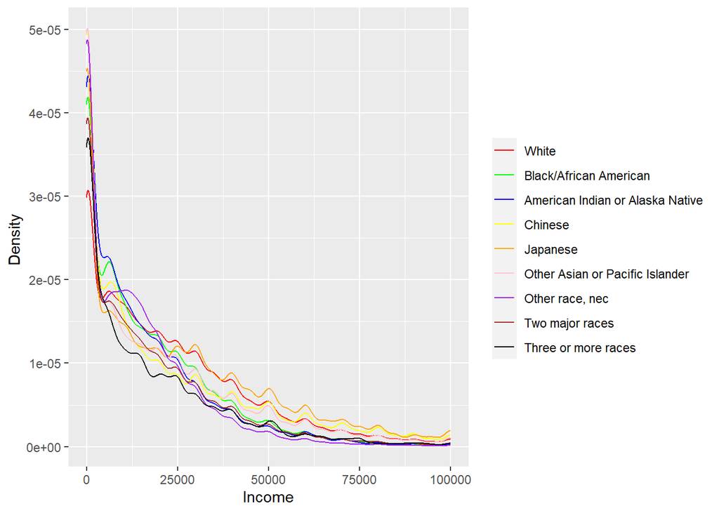

## **Conclusion**

This is not enough to comment on the claim of the study we presented at the beginning. In fact, we should more concentrate on the rate of employment than the income to face the problematic the study had. We also could take a subset of data concerning the part of the population with less education (until grade 10th approximately, as we saw with KDE) and analyse this subsets with respect to the different origins.

Overall, we observed a clear effect of the education level on the income. On the other hand, the origin of the subject appeared to be almost irrelevant to explain the variability in income. To explain the remaining variability between the different origins, it would be interesting to observe how each origin category is distributed among the education levels.